# Downloading Precip Data in Colorado

Keian Freshwater

28 March, 2022

# Precipitation Data Download

# Download and data check

Precipitation from Colorado airport weather stations are downloaded using the following code block.

```r
network <- riem_networks()

co_stations <- riem_stations(network = 'CO_ASOS') %>%
  st_as_sf(., coords = c('lon','lat'), crs = 4326)
glimpse(co_stations)
```

```
## Rows: 73
## Columns: 27
## $ index         <int> 0, 1, 2, 3, 4, 5, 6, 7, 8, 9, 10, 11, 12, 13, 14, 15, 16~
## $ id            <chr> "AFF", "AKO", "ALS", "ASE", "0CO", "BDU", "BJC", "BKF", ~
## $ synop         <dbl> 93065, 24015, 23061, 93073, 419, 160, 3065, 23036, 3064,~
## $ name          <chr> "AIR FORCE ACADEMY", "AKRON/WASHINGTON CO", "ALAMOSA MUN~
## $ state         <chr> "CO", "CO", "CO", "CO", "CO", "CO", "CO", "CO", "CO", "C~
## $ country       <chr> "US", "US", "US", "US", "US", "US", "US", "US", "US", "U~
## $ elevation     <dbl> 2003.000, 1431.000, 2299.000, 2382.000, 3792.000, 1612.0~
## $ network       <chr> "CO_ASOS", "CO_ASOS", "CO_ASOS", "CO_ASOS", "CO_ASOS", "~
## $ online        <lgl> TRUE, TRUE, TRUE, TRUE, TRUE, TRUE, TRUE, TRUE, TRUE, TR~
## $ county        <chr> "El Paso", "Washington", "Alamosa", "Gunnison", "Clear C~
## $ climate_site  <chr> "COTCOS", "CO0114", "CO0130", "CO1959", "CO1186", "CO084~
## $ wfo           <chr> "PUB", "BOU", "PUB", "GJT", "BOU", "BOU", "BOU", "BOU", ~
## $ modified      <chr> "2021-05-05T10:48:22Z", "2021-05-05T10:48:22Z", "2021-05~
## $ spri          <int> 0, 0, 0, 0, 0, 0, 0, 0, 0, 0, 0, 0, 0, 0, 0, 0, 0, 0, 0,~
## $ tzname        <chr> "America/Denver", "America/Denver", "America/Denver", "A~
## $ iemid         <int> 34687, 34688, 34689, 9415, 22652, 22664, 9436, 21855, 90~
## $ archive_begin <chr> "1967-11-27T17:00:00Z", "1948-01-01T07:00:00Z", "1948-01~
## $ metasite      <lgl> FALSE, FALSE, FALSE, FALSE, FALSE, FALSE, FALSE, FALSE, ~
## $ ugc_county    <chr> "COC041", "COC121", "COC003", "COC097", "COC019", "COC01~
## $ ugc_zone      <chr> "COZ226", "COZ249", "COZ070", "COZ203", "COZ034", "COZ23~
## $ ncdc81        <chr> "USC00055734", "USW00024015", "USW00023061", "USW0009307~
## $ ncei91        <chr> "USC00050756", "USW00024015", "USW00023061", "USW0009307~
## $ longitude     <dbl> -104.8128, -103.2220, -105.8614, -106.8689, -105.7639, -~
## $ latitude      <dbl> 38.96972, 40.17563, 37.43889, 39.22317, 39.79388, 40.039~
## $ plot_name     <chr> NA, NA, NA, NA, "Bethoud Pass", "Boulder", NA, NA, "BUEN~
## $ archive_end   <chr> NA, NA, NA, NA, NA, NA, NA, NA, NA, NA, NA, NA, NA, NA, ~
## $ geometry      <POINT [°]> POINT (-104.8128 38.96972), POINT (-103.222 40.175~
```

## Interactive map

Based on the data from the preceding code block, the spatial location of all Colorado airport weather stations are physically mapped below.

```r
mapview(co_stations)
```

[interactive chart not shown]

## Static map

### Download some state boundary data

The following code block downloads the counties within Colorado.

```r
co <- us_counties(
                  states = 'Colorado')
co_elev <- elevatr::get_elev_raster(co_stations,
                                  z = 9 )
```

The following code black adds Colorado Counties to the map of airport weather stations, albeit in a static fashion.

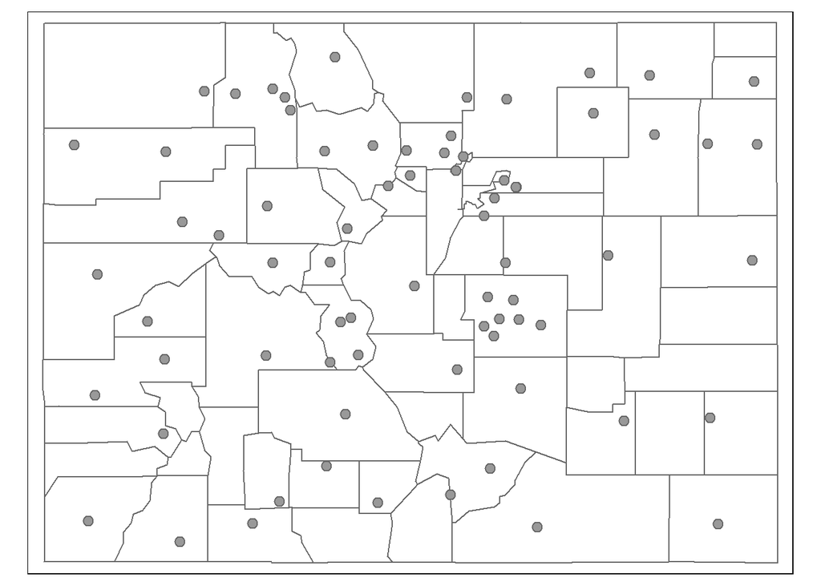

```r
tm_shape(co) +
  tm_polygons(col = 'white') +
tm_shape(co_stations) +
  tm_bubbles(size = 0.2)
```